[OHI Science](http://ohi-science.org) | [Citation policy](http://ohi-science.org/citation-policy/)

# OHI-Northeast: Region Options for the September 21 workshop

Compiled on Thu Sep 7 15:00:25 2017 by afflerbach

*Three different region options are presented here*:

1. Whole region, each state (that wants a score), each offshore EPU
2. Whole region, state waters north of the Cape, state waters south of the Cape, each offshore EPU
3. Whole region, each offshore EPU

# 1 Load data

## 1.1 State boundaries and water

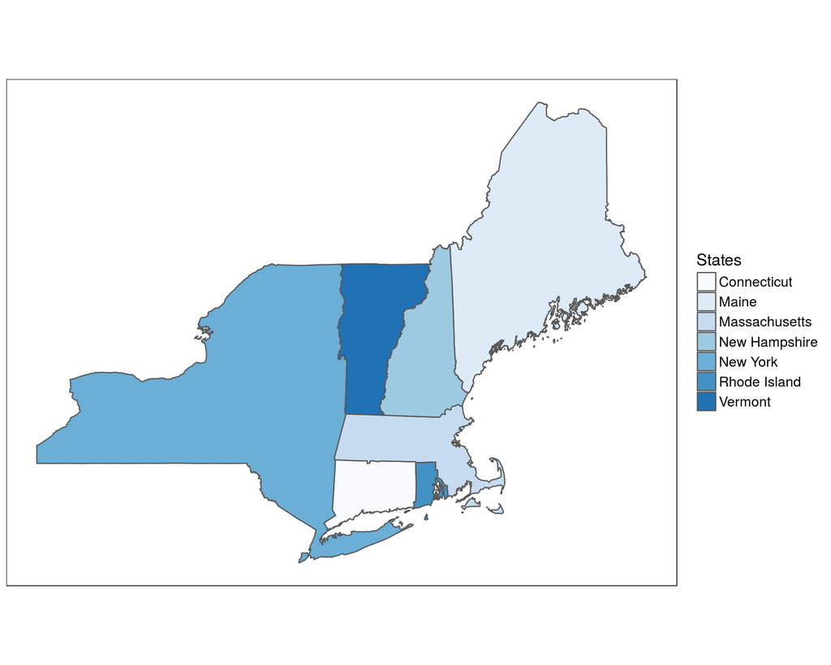

## 1.2 Northeast Ocean Plan Study Area

Emily emailed this shapefile to us to use as the NE Ocean Plan study area. State waters are not included in this shapefile but we need to include state waters within the larger NE study area.

## 1.3 Canada EEZ

## 1.4 US EEZ

Also need to grab the tip of maine and add it to the Scotian Shelf EPU

## 1.5 Ecological Production Units

The EPU’s don’t encompass all of Maine’s waters up to the border with Canada. I’m using the EEZ to extend the Northernmost EPU to Canada.

# 2 Option 1

Just the Northeast planning region

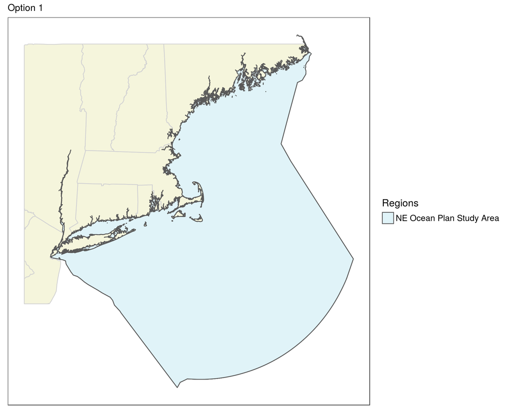

# 3 Option 2

Whole region, each offshore EPU

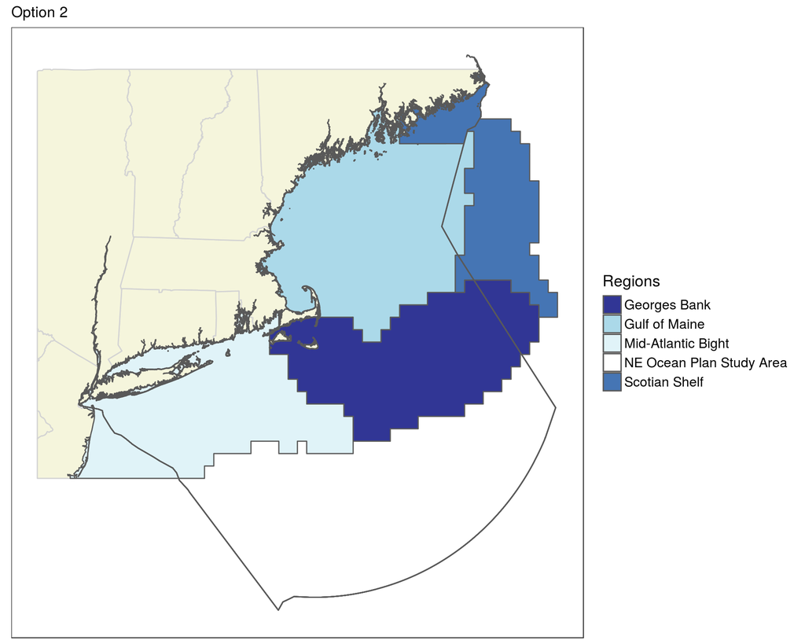

# 4 Option 3

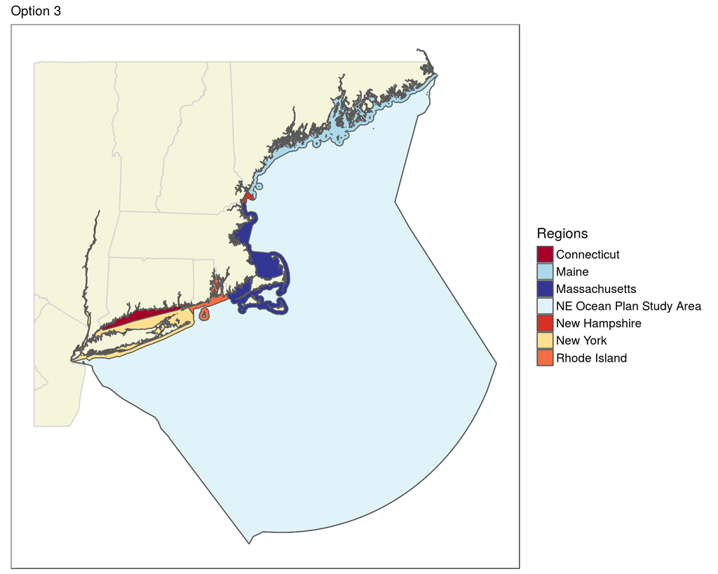

# 5 Option 4

Whole region, state waters north of the Cape, state waters south of the Cape, each offshore EPU

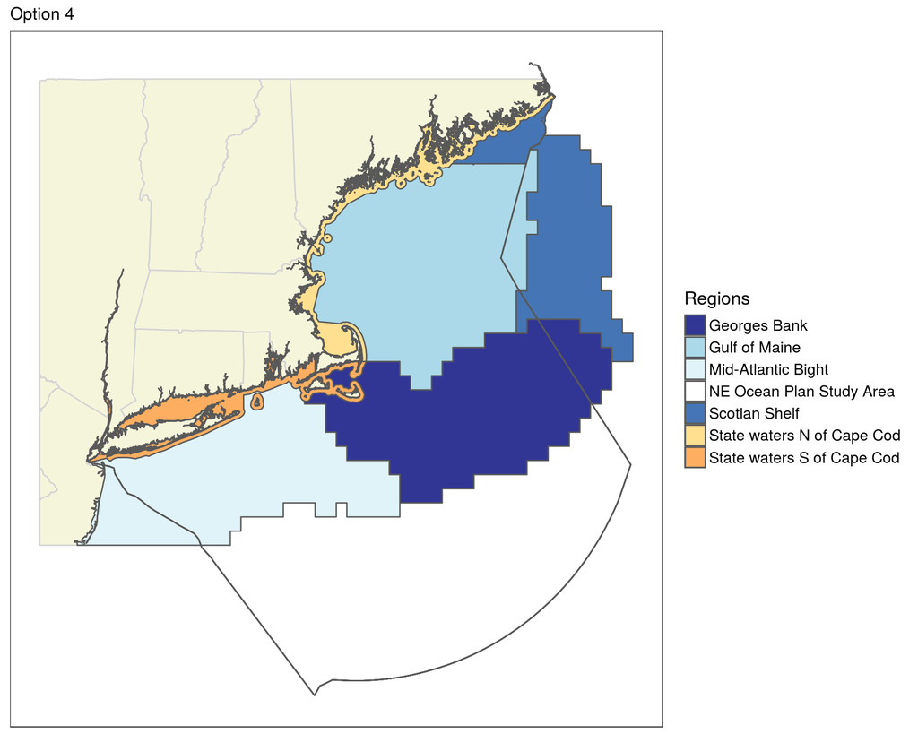

# 6 Overlap of Canada

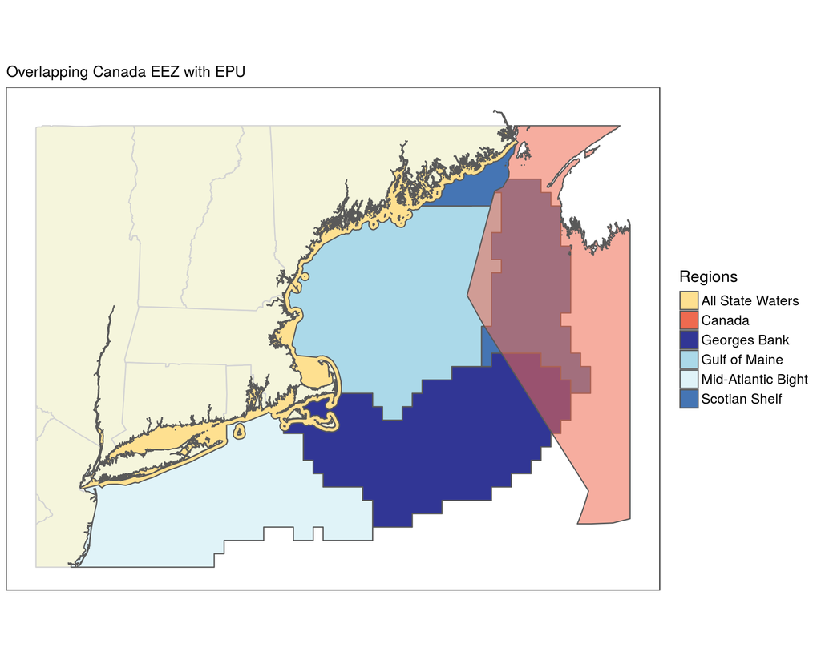

# 7 Aggregate EPUS

```
## [1] "sf"         "data.frame"
```

```
## Geometry set for 1 feature
## geometry type:  MULTIPOLYGON
## dimension:      XY
## bbox:           xmin: -74.45438 ymin: 39.5 xmax: -65.66667 ymax: 45
## epsg (SRID):    4269
## proj4string:    +proj=longlat +ellps=GRS80 +towgs84=0,0,0,0,0,0,0 +no_defs
```

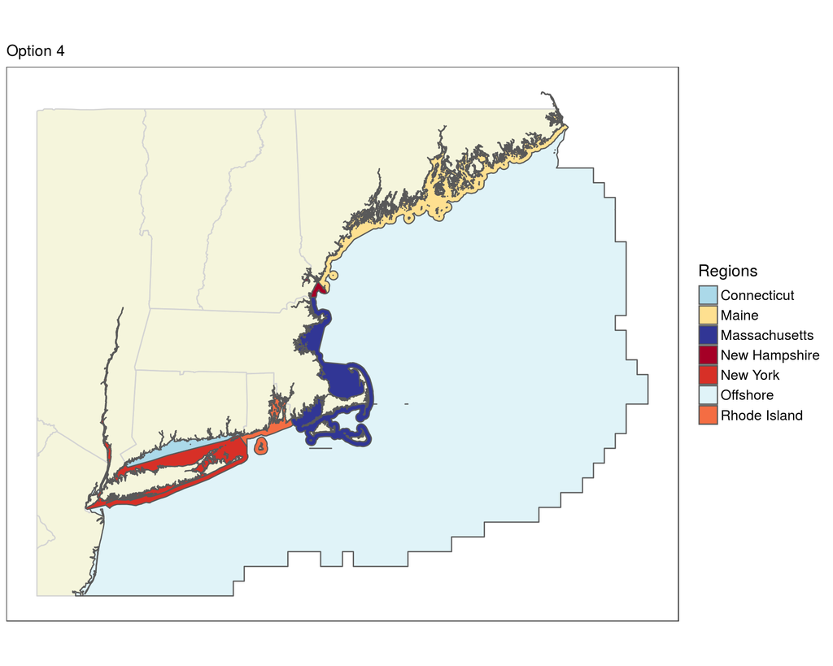

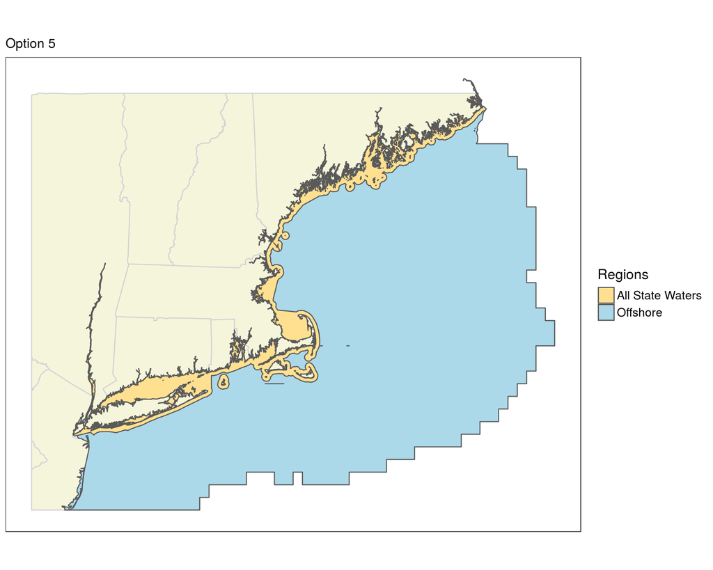

# 8 Coastal County and State Map

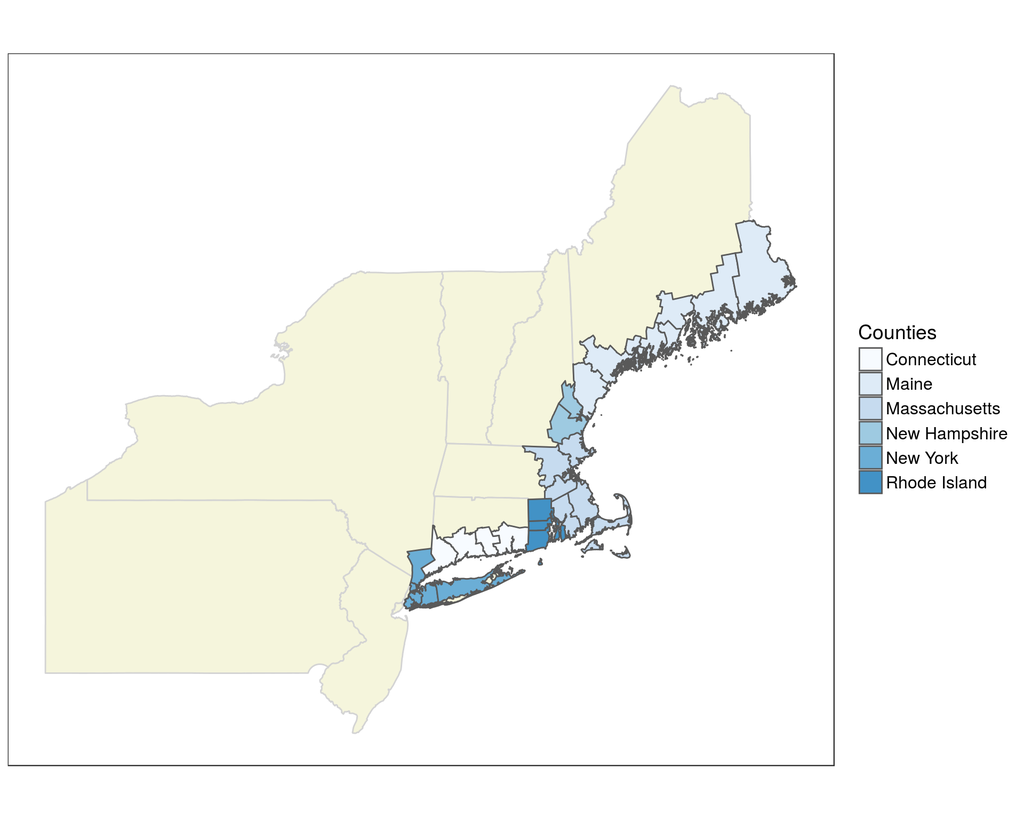